# Exploratory Analysis of Efficiency in Buildings Dataset

Diego Quintana, Manuel Breve, Marcel Pons

2020-05-13

```r
# starting from scratch
rm(list=ls())
knitr::opts_chunk$set(echo = TRUE, include = TRUE, message = FALSE, warning = FALSE)
```

```r
# imports for the project
library(mice) # for imputing missing data
library(psych)
library(ggplot2) # for an improved toolset for plots
library(tableplot)
library(reshape2)
library(chemometrics) # for the mahalanobis distance
library(pracma)
library(PerformanceAnalytics) # to plot histograms
library(dplyr) # for an improved toolset


# clustering
library(FactoMineR)
library(factoextra)
library(plotrix)
library(gplots)
library(tableplot)


set.seed(42)
# add a new comment here
```

# 1 About

From UCI’s Machine Learning repository description in https://archive.ics.uci.edu/ml/datasets/Energy+efficiency

> Abstract: This study looked into assessing the heating load and cooling load requirements of buildings (that is, energy efficiency) as a function of building parameters.

> We perform energy analysis using 12 different building shapes simulated in Ecotect. The buildings differ with respect to the glazing area, the glazing area distribution, and the orientation, amongst other parameters. We simulate various settings as functions of the afore-mentioned characteristics to obtain 768 building shapes. The dataset comprises 768 samples and 8 features, aiming to predict two real valued responses. It can also be used as a multi-class classification problem if the response is rounded to the nearest integer.

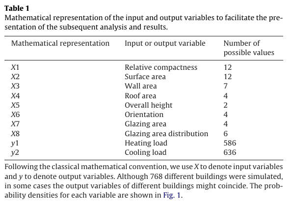

Summary from the paper

```r
energy <- readxl::read_xlsx("data/ENB2012_data.xlsx")
head(energy)
```

| X1 | X2 | X3 | X4 | X5 | X6 | X7 | X8 | Y1 | Y2 |
| --- | --- | --- | --- | --- | --- | --- | --- | --- | --- |
| 0.98 | 514.5 | 294.0 | 110.25 | 7 | 2 | 0 | 0 | 15.55 | 21.33 |
| 0.98 | 514.5 | 294.0 | 110.25 | 7 | 3 | 0 | 0 | 15.55 | 21.33 |
| 0.98 | 514.5 | 294.0 | 110.25 | 7 | 4 | 0 | 0 | 15.55 | 21.33 |
| 0.98 | 514.5 | 294.0 | 110.25 | 7 | 5 | 0 | 0 | 15.55 | 21.33 |
| 0.90 | 563.5 | 318.5 | 122.50 | 7 | 2 | 0 | 0 | 20.84 | 28.28 |
| 0.90 | 563.5 | 318.5 | 122.50 | 7 | 3 | 0 | 0 | 21.46 | 25.38 |

> The dataset contains eight attributes (or features, denoted by X1…X8) and two responses (or outcomes, denoted by y1 and y2). The aim is to use the eight features to predict each of the two responses.

```r
class(energy)
```

```
## [1] "tbl_df"     "tbl"        "data.frame"
```

Specifically: X1 Relative Compactness X2 Surface Area X3 Wall Area X4 Roof Area X5 Overall Height X6 Orientation X7 Glazing Area X8 Glazing Area Distribution y1 Heating Load y2 Cooling Load

```r
colnames(energy)
```

```
##  [1] "X1" "X2" "X3" "X4" "X5" "X6" "X7" "X8" "Y1" "Y2"
```

```r
colnames(energy) <- c("X1.RelativeCompactness",
"X2.SurfaceArea",
"X3.WallArea",
"X4.RoofArea",
"X5.OverallHeight",
"X6.Orientation",
"X7.GlazingArea",
"X8.GlazingAreaDistribution",
"y1.HeatingLoad",
"y2.CoolingLoad")

head(energy)
```

| X1.RelativeCompactness | X2.SurfaceArea | X3.WallArea | X4.RoofArea | X5.OverallHeight | X6.Orientation | X7.GlazingArea | X8.GlazingAreaDistribution | y1.HeatingLoad | y2.CoolingLoad |
| --- | --- | --- | --- | --- | --- | --- | --- | --- | --- |
| 0.98 | 514.5 | 294.0 | 110.25 | 7 | 2 | 0 | 0 | 15.55 | 21.33 |
| 0.98 | 514.5 | 294.0 | 110.25 | 7 | 3 | 0 | 0 | 15.55 | 21.33 |
| 0.98 | 514.5 | 294.0 | 110.25 | 7 | 4 | 0 | 0 | 15.55 | 21.33 |
| 0.98 | 514.5 | 294.0 | 110.25 | 7 | 5 | 0 | 0 | 15.55 | 21.33 |
| 0.90 | 563.5 | 318.5 | 122.50 | 7 | 2 | 0 | 0 | 20.84 | 28.28 |
| 0.90 | 563.5 | 318.5 | 122.50 | 7 | 3 | 0 | 0 | 21.46 | 25.38 |

```r
describe(energy)
```

|  | vars | n | mean | sd | median | trimmed | mad | min | max | range | skew | kurtosis | se |
| --- | --- | --- | --- | --- | --- | --- | --- | --- | --- | --- | --- | --- | --- |
| X1.RelativeCompactness | 1 | 768 | 0.7641667 | 0.1057775 | 0.75 | 0.7564935 | 0.118608 | 0.62 | 0.98 | 0.36 | 0.4935786 | -0.7157384 | 0.0038169 |
| X2.SurfaceArea | 2 | 768 | 671.7083333 | 88.0861161 | 673.75 | 673.7500000 | 108.971100 | 514.50 | 808.50 | 294.00 | -0.1246425 | -1.0654194 | 3.1785339 |
| X3.WallArea | 3 | 768 | 318.5000000 | 43.6264814 | 318.50 | 315.9545455 | 36.323700 | 245.00 | 416.50 | 171.50 | 0.5313356 | 0.0999447 | 1.5742351 |
| X4.RoofArea | 4 | 768 | 176.6041667 | 45.1659502 | 183.75 | 179.1363636 | 54.485550 | 110.25 | 220.50 | 110.25 | -0.1621288 | -1.7763946 | 1.6297858 |
| X5.OverallHeight | 5 | 768 | 5.2500000 | 1.7511404 | 5.25 | 5.2500000 | 2.594550 | 3.50 | 7.00 | 3.50 | 0.0000000 | -2.0026025 | 0.0631888 |
| X6.Orientation | 6 | 768 | 3.5000000 | 1.1187626 | 3.50 | 3.5000000 | 1.482600 | 2.00 | 5.00 | 3.00 | 0.0000000 | -1.3642681 | 0.0403699 |
| X7.GlazingArea | 7 | 768 | 0.2343750 | 0.1332206 | 0.25 | 0.2383117 | 0.222390 | 0.00 | 0.40 | 0.40 | -0.0600191 | -1.3311582 | 0.0048072 |
| X8.GlazingAreaDistribution | 8 | 768 | 2.8125000 | 1.5509597 | 3.00 | 2.8441558 | 1.482600 | 0.00 | 5.00 | 5.00 | -0.0883430 | -1.1538633 | 0.0559654 |
| y1.HeatingLoad | 9 | 768 | 22.3071953 | 10.0902040 | 18.95 | 21.7143994 | 11.141739 | 6.01 | 43.10 | 37.09 | 0.3590389 | -1.2498432 | 0.3640989 |
| y2.CoolingLoad | 10 | 768 | 24.5877604 | 9.5133056 | 22.08 | 23.9455032 | 11.178804 | 10.90 | 48.03 | 37.13 | 0.3944470 | -1.1523586 | 0.3432818 |

## 1.1 Converting categorical variables

Continous variables: X1,X2,X3,X4,X5,X7

Categorical variables: X6: 4 types of orientation: North, East, South, West X8: 6 types of glazing area distribution: Uniform, North, East, South, West and No Glazing areas.

> We used three types of glazing areas, which are expressed as percentages of the floor area: 10%, 25%, and 40%. Furthermore, five different distribution scenarios for each glazing area were simu- lated: (1) uniform: with 25% glazing on each side, (2) north: 55% on the north side and 15% on each of the other sides, (3) east: 55% on the east side and 15% on each of the other sides, (4) south: 55% on the south side and 15% on each of the other sides, and (5) west: 55% on the west side and 15% on each of the other sides. In addition, we obtained samples with no glazing areas. Finally, all shapes were rotated to face the four cardinal points.

```r
energy$X6.Orientation <- factor(energy$X6.Orientation, levels=2:5, labels = c('North','East', 'South','West'))
energy$X8.GlazingAreaDistribution <- factor(energy$X8.GlazingAreaDistribution, levels = 0:5, labels = c("No Glazing", "Uniform", 'North','East', 'South','West'))
```

## 1.2 Separating in continuous and categorical data

```r
energy.continous <- select(energy, -grep("^X[6,8]", colnames(energy)))
```

## 1.3 Separating datasets in inputs and response variables

```r
energy.X <- energy[,-grep("Load$", colnames(energy.continous))]
energy.y <- energy[,grep("Load$", colnames(energy.continous))]
```

## 1.4 Imputing missing data

```r
md.pattern(energy, plot = FALSE)
```

```
##  /\     /\
## {  `---'  }
## {  O   O  }
## ==>  V <==  No need for mice. This data set is completely observed.
##  \  \|/  /
##   `-----'
```

```
##     X1.RelativeCompactness X2.SurfaceArea X3.WallArea X4.RoofArea
## 768                      1              1           1           1
##                          0              0           0           0
##     X5.OverallHeight X6.Orientation X7.GlazingArea X8.GlazingAreaDistribution
## 768                1              1              1                          1
##                    0              0              0                          0
##     y1.HeatingLoad y2.CoolingLoad
## 768              1              1 0
##                  0              0 0
```

## 1.5 Data visualizations

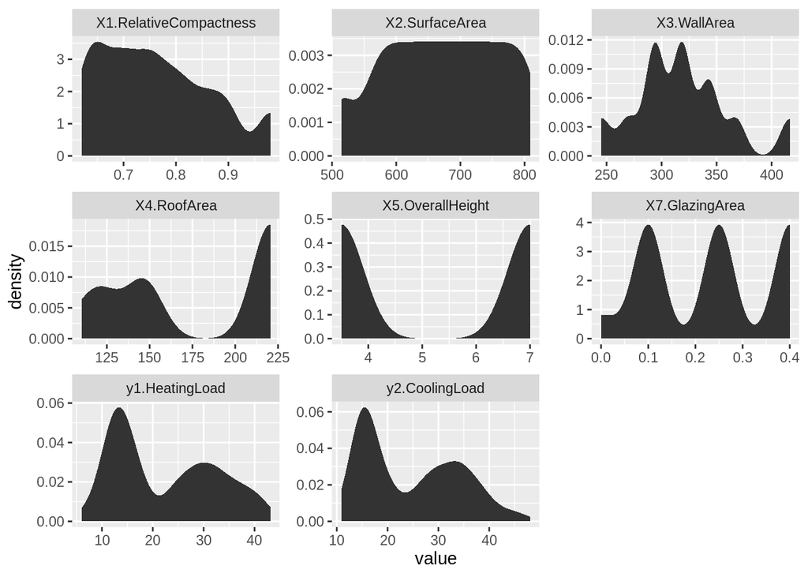

```r
# https://datacritics.com/2018/02/28/melt-your-data-for-fast-visuals-with-your-dataset-in-r/
melt.energy <- melt(energy)
ggplot(data = melt.energy, aes(x = value)) +
  stat_density() +
  facet_wrap(~variable, scales = "free")
```

## 1.6 Outlier Detection

### 1.6.1 Univariate outlier analysis

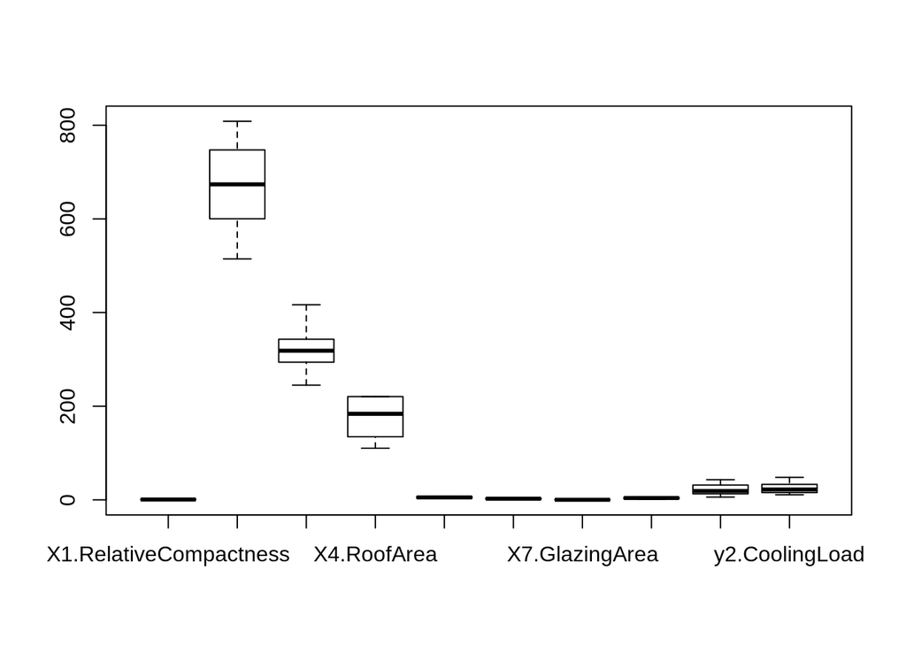

```r
# https://stackoverflow.com/questions/44089894/identifying-the-outliers-in-a-data-set-in-r
OutVals <-  boxplot(energy)$out
```

```r
which(energy %in% OutVals)
```

```
## integer(0)
```

### 1.6.2 Using mahalanobis distances (covariance matrix is singular, find out what it means)

```r
# normalize dataset
m <- energy.X
m <- scale(m, center=TRUE, scale=colSums(m))
Moutlier(m, quantile = 0.975, plot = TRUE)
```

This matrix is not invertible. Two fundamental linear algebra properties:

- A singular (square) matrix is a (square) matrix that is not invertible.
- A matrix is not invertible if its determinant equals zero.

We can check the condition number

```r
# https://stackoverflow.com/questions/50928796/system-is-computationally-singular-reciprocal-condition-number-in-r
# https://en.wikipedia.org/wiki/Condition_number
# https://stats.stackexchange.com/questions/37743/singular-covariance-matrix-in-mahalanobis-distance-in-matlab
kappa(as.matrix(energy.X))
```

[output not shown]

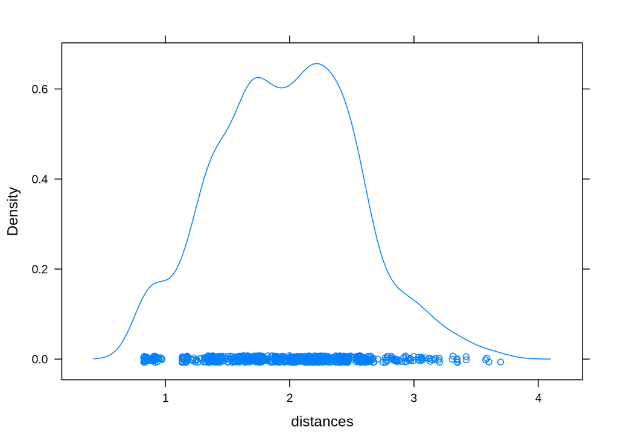

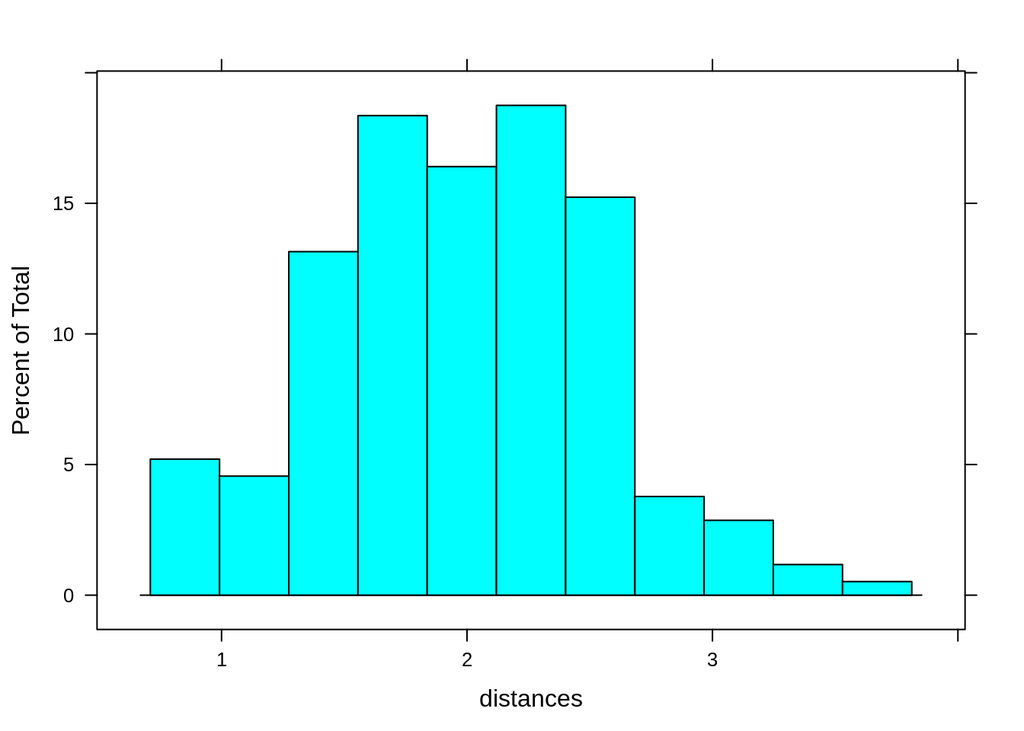

```r
mahalanobis2 <- function(energy,
                         inv.pseudo = FALSE,
                         robust = TRUE,
                         plot = TRUE,
                         tol = 0.975) {
  # we can use the penrose-moore pseudoinverse instead of the normal inverse
  # https://stats.stackexchange.com/a/37810/101414

  # cite this as
  # kjetil b halvorsen (https://stats.stackexchange.com/users/11887/kjetil-b-halvorsen), Singular covariance matrix in Mahalanobis distance in Matlab, URL (version: 2012-09-22): https://stats.stackexchange.com/q/37810

  if (robust == TRUE) {
    # Uses the MCD estimator, according to

    # Mia Hubert, Peter J. Rousseeuw, Stefan Van Aelst,
    # 10 - Multivariate Outlier Detection and Robustness,
    # Editor(s): C.R. Rao, E.J. Wegman, J.L. Solka,
    # Handbook of Statistics,
    # Elsevier,
    # Volume 24,
    # 2005,
    # Pages 263-302,
    # ISSN 0169-7161,
    # ISBN 9780444511416,
    # https://doi.org/10.1016/S0169-7161(04)24010-X.

    # produce the MCD estimates
    energy.mcd <- robustbase::covMcd(energy)

    # center vectors using the MCD estimator
    xMinusM <- sweep(energy, 2L, energy.mcd$center)
    xMinusMTransposed <- t(xMinusM)

    if (inv.pseudo == TRUE) {
      inverseCovMatrix <- pinv(energy.mcd$cov)
    } else {
      # using normal inverse
      inverseCovMatrix <- solve(energy.mcd$cov)
    }

    left <- as.matrix(xMinusM) %*% as.matrix(inverseCovMatrix)
    mdSquared <- left %*% as.matrix(xMinusMTransposed)
    mdSquaredDiag <- diag(mdSquared)

  }
  else {
    # using classic mahalanobis
    xMinusM <- scale(energy, scale = FALSE)

    xMinusMTransposed <- t(xMinusM)

    if (inv.pseudo == TRUE) {
      inverseCovMatrix <- pinv(var(energy))
    } else {
      inverseCovMatrix <- solve(var(energy))
    }
    left <- xMinusM %*% inverseCovMatrix
    mdSquared <- left %*% xMinusMTransposed
    mdSquaredDiag <- diag(mdSquared)
  }

  distances <- sqrt(mdSquaredDiag)

  # defining threshold
  threshold <- sqrt(qchisq(tol, ncol(energy)))
  energy$isOutlier <- (distances >= threshold)

  if (plot == TRUE){
    plot(densityplot(distances))
    plot(histogram(distances))
    # plot(energy, col = energy$isOutlier)
    # legend(7,4.3,unique(energy$isOutlier),col=1:length(energy$isOutlier),pch=1)
    }



  wrapper <- NULL
  wrapper$distances <- distances
  wrapper$isOutlier <- energy$isOutlier
  wrapper$threshold <- threshold
  return(wrapper)
}

mdRobustDistances <- mahalanobis2(energy.continous, robust = TRUE, inv.pseudo = TRUE, plot = TRUE)
```

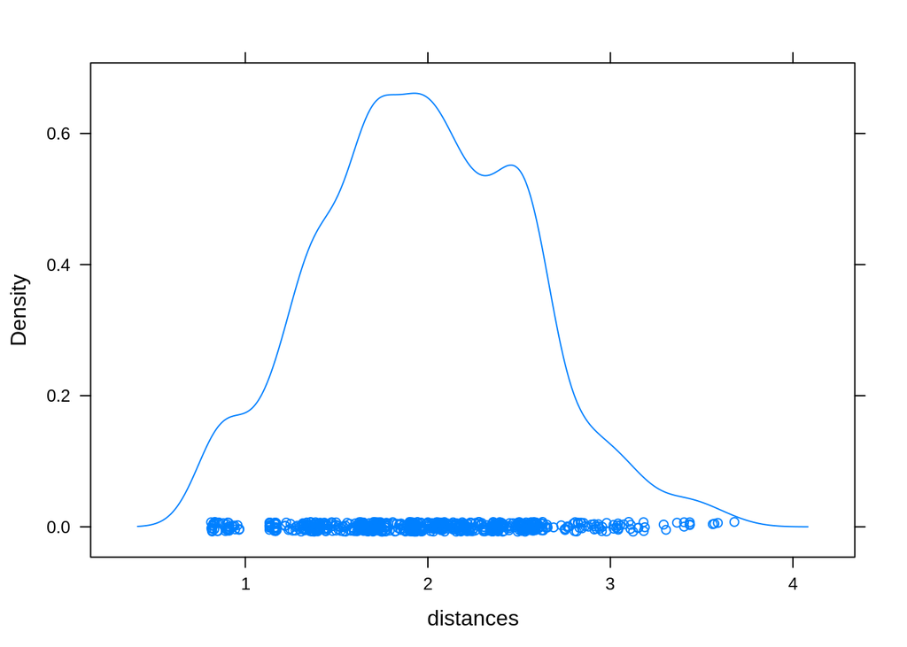

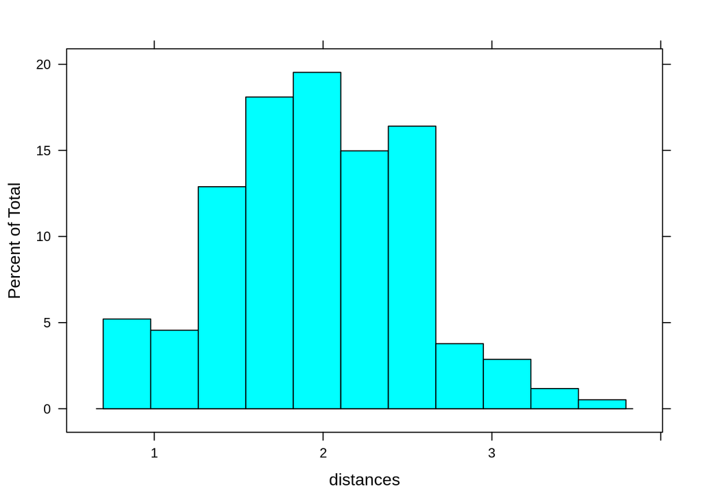

```r
mdRobustDistances <- mahalanobis2(energy.continous, robust = TRUE, inv.pseudo = FALSE, plot = TRUE)
```

We can assume there are no outliers.

```r
length(mdRobustDistances[mdRobustDistances$isOutlier == TRUE])
```

```
## [1] 0
```

## 1.7 Histograms

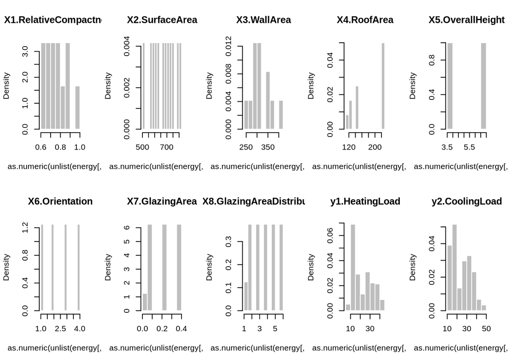

```r
par(mfrow=c(2, 5))
colnames <- colnames(energy)
for (i in 1:10) {
    hist(as.numeric(unlist(energy[,i])), main=colnames[i], probability=TRUE, col="gray", border="white")
}
```

## 1.8 Check Correlations

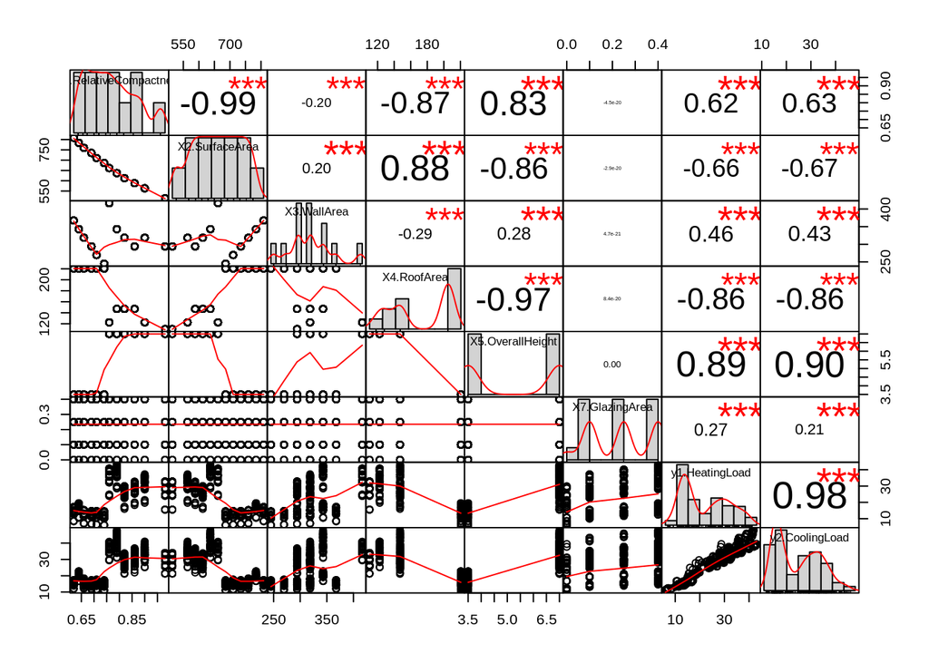

```r
# not considering categorical variables
chart.Correlation(energy.continous, histogram=TRUE)
```

## 1.9 Dealing with multicollinearity

The outlier detection here needs revision. We observed the following

1. the dataset has a near singular covariance matrix: this means that there are linearly dependant rows or attributes in the dataset. See
2. https://stats.stackexchange.com/questions/464477/how-to-perform-multivariate-analysis-on-datasets-with-singular-covariance-matrix?noredirect=1#comment858869_464477 for a question about this specific topic.
3. https://stats.stackexchange.com/questions/70899/what-correlation-makes-a-matrix-singular-and-what-are-implications-of-singularit/70910#70910 about the implications of having a singular covariance matrix.
4. This means that we are in presence of multicollinearity, e.g. the `vif` is not available.

```r
hldata <- select(energy, -(y2.CoolingLoad))
cldata <- select(energy, -(y1.HeatingLoad))

library(car)
hlmodel <- lm(y1.HeatingLoad ~ . , data=hldata)
clmodel <- lm(y2.CoolingLoad ~ . , data=cldata)
```

```r
car::vif(hlmodel) # raises an exception, there are aliased coefficients in the model
```

```r
summary(hlmodel)
```

```
##
## Call:
## lm(formula = y1.HeatingLoad ~ ., data = hldata)
##
## Residuals:
##     Min      1Q  Median      3Q     Max
## -7.1237 -1.4299 -0.2555  1.2972  7.4342
##
## Coefficients: (1 not defined because of singularities)
##                                     Estimate Std. Error t value Pr(>|t|)
## (Intercept)                        81.161469  18.189282   4.462 9.36e-06 ***
## X1.RelativeCompactness            -64.773432   9.832563  -6.588 8.38e-11 ***
## X2.SurfaceArea                     -0.087289   0.016317  -5.350 1.17e-07 ***
## X3.WallArea                         0.060813   0.006353   9.573  < 2e-16 ***
## X4.RoofArea                               NA         NA      NA       NA
## X5.OverallHeight                    4.169954   0.322982  12.911  < 2e-16 ***
## X6.OrientationEast                  0.067812   0.286185   0.237    0.813
## X6.OrientationSouth                -0.052990   0.286185  -0.185    0.853
## X6.OrientationWest                 -0.037500   0.286185  -0.131    0.896
## X7.GlazingArea                     16.848333   0.853238  19.746  < 2e-16 ***
## X8.GlazingAreaDistributionUniform   4.527653   0.513717   8.814  < 2e-16 ***
## X8.GlazingAreaDistributionNorth     4.435986   0.513717   8.635  < 2e-16 ***
## X8.GlazingAreaDistributionEast      4.183000   0.513717   8.143 1.60e-15 ***
## X8.GlazingAreaDistributionSouth     4.388208   0.513717   8.542  < 2e-16 ***
## X8.GlazingAreaDistributionWest      4.182444   0.513717   8.142 1.61e-15 ***
## ---
## Signif. codes:  0 '***' 0.001 '**' 0.01 '*' 0.05 '.' 0.1 ' ' 1
##
## Residual standard error: 2.804 on 754 degrees of freedom
## Multiple R-squared:  0.9241, Adjusted R-squared:  0.9228
## F-statistic:   706 on 13 and 754 DF,  p-value: < 2.2e-16
```

```r
alias(hlmodel)
```

```
## Model :
## y1.HeatingLoad ~ X1.RelativeCompactness + X2.SurfaceArea + X3.WallArea +
##     X4.RoofArea + X5.OverallHeight + X6.Orientation + X7.GlazingArea +
##     X8.GlazingAreaDistribution
##
## Complete :
##             (Intercept) X1.RelativeCompactness X2.SurfaceArea X3.WallArea
## X4.RoofArea    0           0                    1/2           -1/2
##             X5.OverallHeight X6.OrientationEast X6.OrientationSouth
## X4.RoofArea    0                0                  0
##             X6.OrientationWest X7.GlazingArea X8.GlazingAreaDistributionUniform
## X4.RoofArea    0                  0              0
##             X8.GlazingAreaDistributionNorth X8.GlazingAreaDistributionEast
## X4.RoofArea    0                               0
##             X8.GlazingAreaDistributionSouth X8.GlazingAreaDistributionWest
## X4.RoofArea    0                               0
```

We get that roof area (`X4.RoofArea`) is correlated with `X2.SurfaceArea` and `X3.WallArea`. The alternatives we have here are

- drop `X4.RoofArea`, probably dropping Surface Area or Wall Area also
- transform `X4.RoofArea` into something uncorrelated. Probably merging those features into one.

For now, let’s just drop `X4.RoofArea`.

```r
hlmodel.2 <- lm(y1.HeatingLoad ~ . -X4.RoofArea , data=hldata)
clmodel.2 <- lm(y2.CoolingLoad ~ . -X4.RoofArea, data=cldata)
```

```r
alias(hlmodel.2) # doesn't seem to have collinearity
```

```
## Model :
## y1.HeatingLoad ~ (X1.RelativeCompactness + X2.SurfaceArea + X3.WallArea +
##     X4.RoofArea + X5.OverallHeight + X6.Orientation + X7.GlazingArea +
##     X8.GlazingAreaDistribution) - X4.RoofArea
```

```r
energy.2 <- select(energy.continous, -(X4.RoofArea))
det(cov(energy.2))
```

```
## [1] 146.1685
```

```r
# [1] 146.1685
```

By dropping X4, we obtain a non singular covariance matrix, and

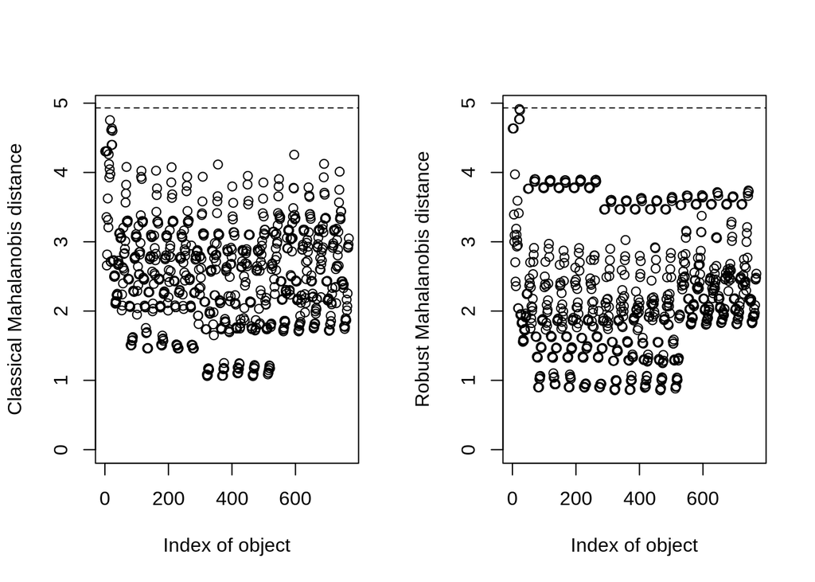

```
## $md
##   [1] 4.304144 4.304144 4.304144 4.304144 3.355897 2.657802 2.816445 4.308984
##   [9] 3.624191 3.315676 3.207992 4.262413 4.120697 3.927454 4.046023 4.755447
##  [17] 3.977241 2.715810 2.708755 4.612054 4.398691 4.635408 4.398691 4.599969
##  [25] 2.726326 2.734244 2.727808 2.733798 2.495148 2.515748 2.496057 2.512193
##  [33] 2.106543 2.142914 2.116013 2.127448 2.232370 2.230308 2.249471 2.221477
##  [41] 2.665076 2.726363 2.671346 2.689434 3.118296 3.125976 3.128817 3.125294
##  [49] 3.051751 3.059855 3.055201 3.063871 2.009528 2.239224 2.078199 2.634297
##  [57] 2.398884 3.202587 2.612193 2.824797 2.583456 2.834880 2.897411 3.010327
##  [65] 3.565857 3.695454 3.823039 4.079640 3.294562 3.303174 3.277427 3.306545
##  [73] 2.468129 2.460289 2.464188 2.454564 2.077980 2.062325 2.071272 2.057542
##  [81] 1.509440 1.503373 1.506023 1.508419 1.571241 1.609008 1.578744 1.624176
##  [89] 2.289330 2.294920 2.285125 2.275554 2.769882 2.751585 2.767485 2.787022
##  [97] 3.077775 3.108809 3.062078 3.081118 1.948253 2.288883 2.041633 2.642797
## [105] 2.375128 3.227768 2.526669 2.848016 2.535007 2.815385 2.854126 2.983019
```

[output cut: 197 more lines]

```r
Moutlier(scale(energy.2, center = TRUE, scale = colSums(energy.2)),
         quantile = 0.999,
         plot = TRUE)
```

Using our custom method

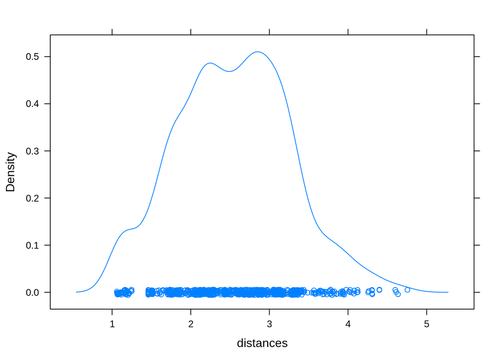

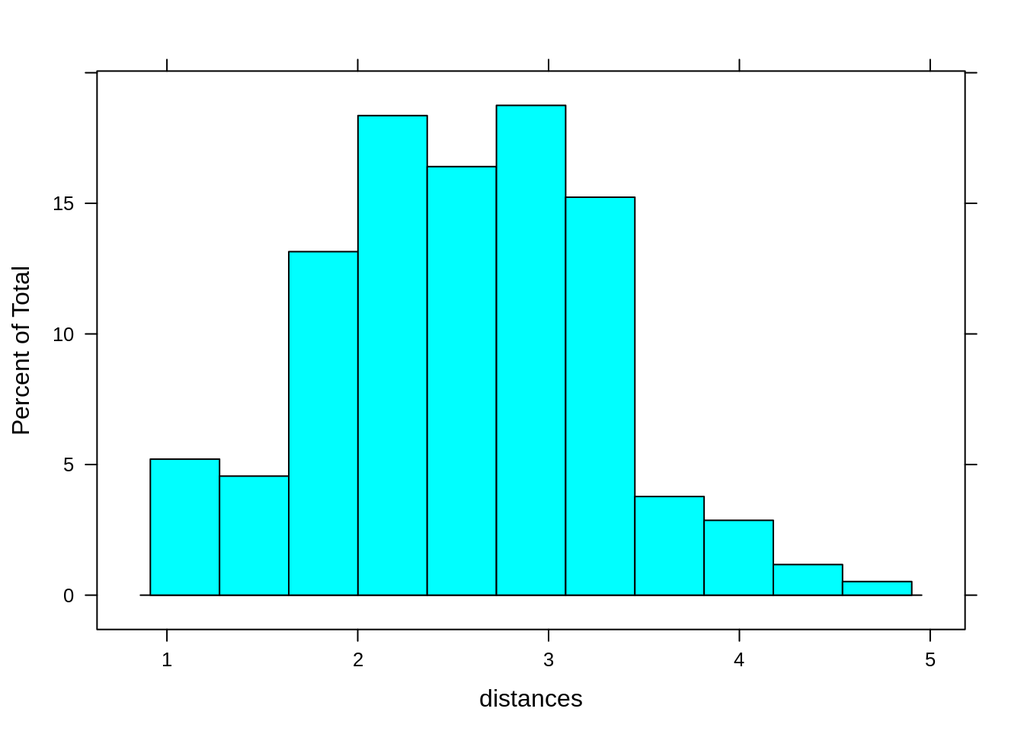

```r
set.seed(42)
mdClassicDistances2 <- mahalanobis2(energy.2, robust = FALSE, inv.pseudo = FALSE, plot = TRUE, tol = 0.999)
```

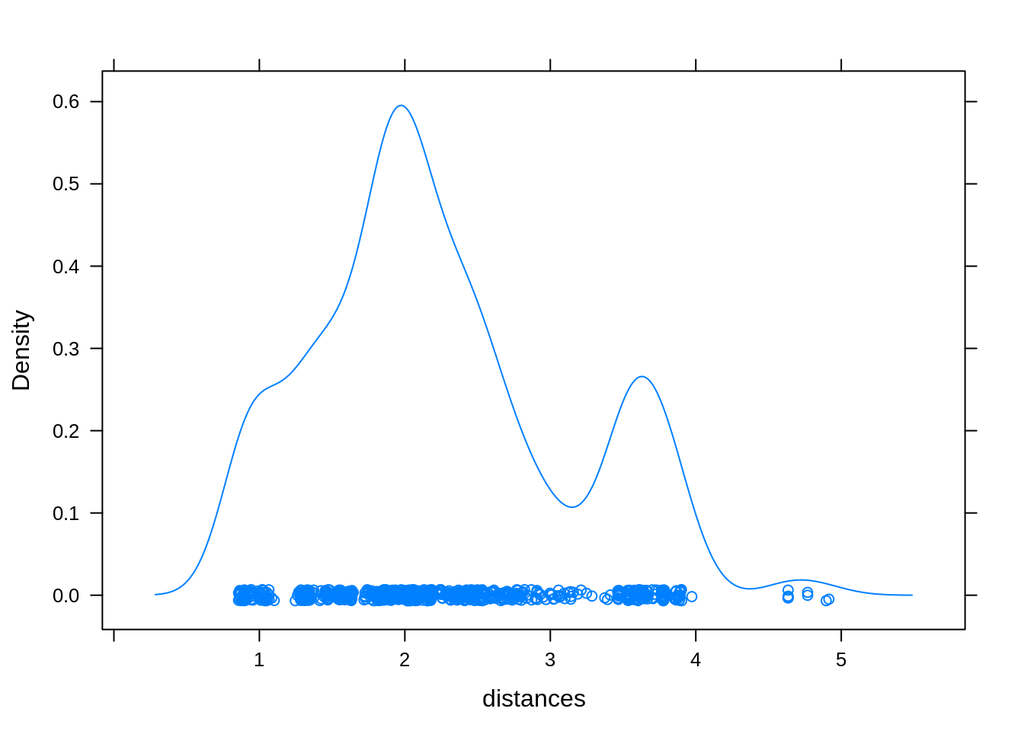

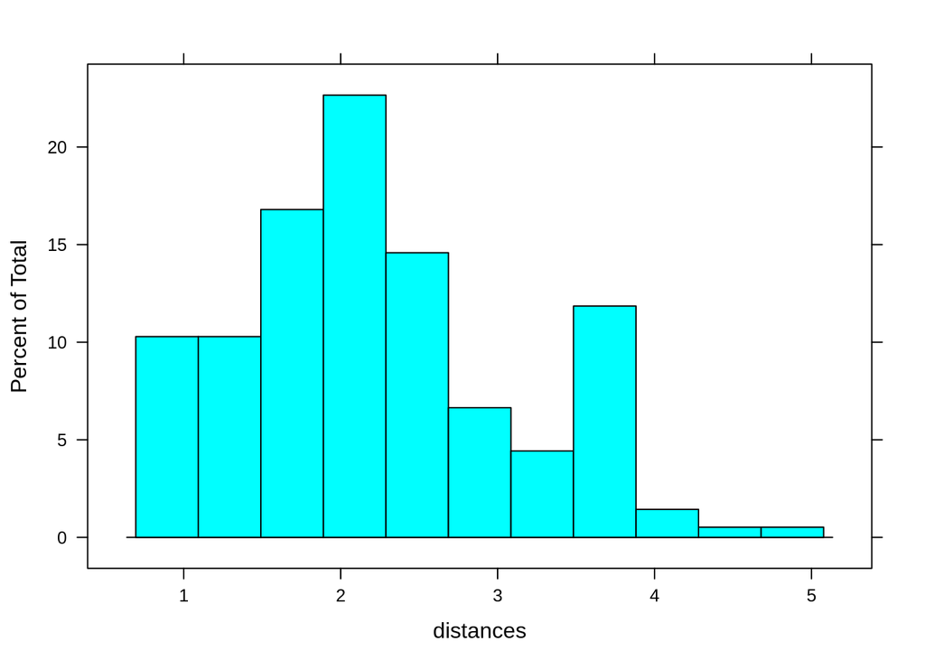

```r
mdRobustDistances2 <- mahalanobis2(energy.2, robust = TRUE, inv.pseudo = FALSE, plot = TRUE, tol = 0.999)
```

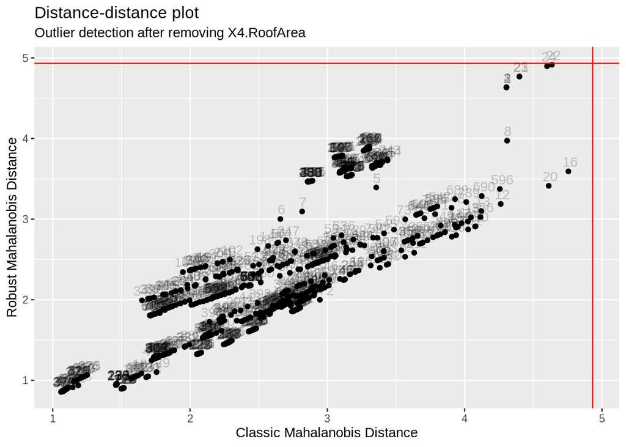

```r
crd <- data.frame(rn = rownames(energy.2), dc = mdClassicDistances2$distances, dr = mdRobustDistances2$distances)
threshold <- mdClassicDistances2$threshold

p <- ggplot(mapping = aes(x = dc, y = dr), data = crd) +
  geom_point() +
  geom_hline(yintercept = threshold, color = "red") +
  geom_vline(xintercept = threshold, color = "red") +
  geom_text(aes(label = rownames(crd)), alpha=0.2, hjust = 0.4, vjust = -0.5) +
  xlab("Classic Mahalanobis Distance") +
  ylab("Robust Mahalanobis Distance") +
  labs(title = "Distance-distance plot") +
  labs(subtitle = "Outlier detection after removing X4.RoofArea")

p
```

# 2 PCA

```r
set.seed(42)
```

```r
targets <- grep("Load$", colnames(energy))
categoricals <- grep("^X[6,8]", colnames(energy))
energy.pca <- PCA(energy, quali.sup = categoricals, quanti.sup = targets, scale.unit = TRUE)
```

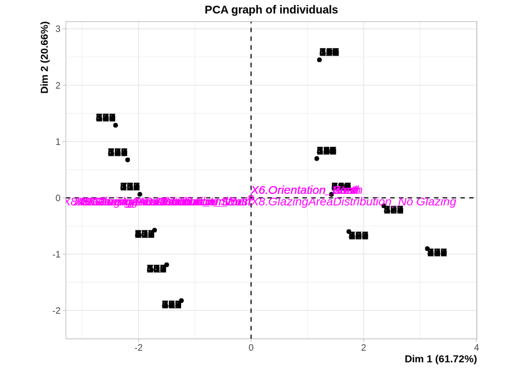

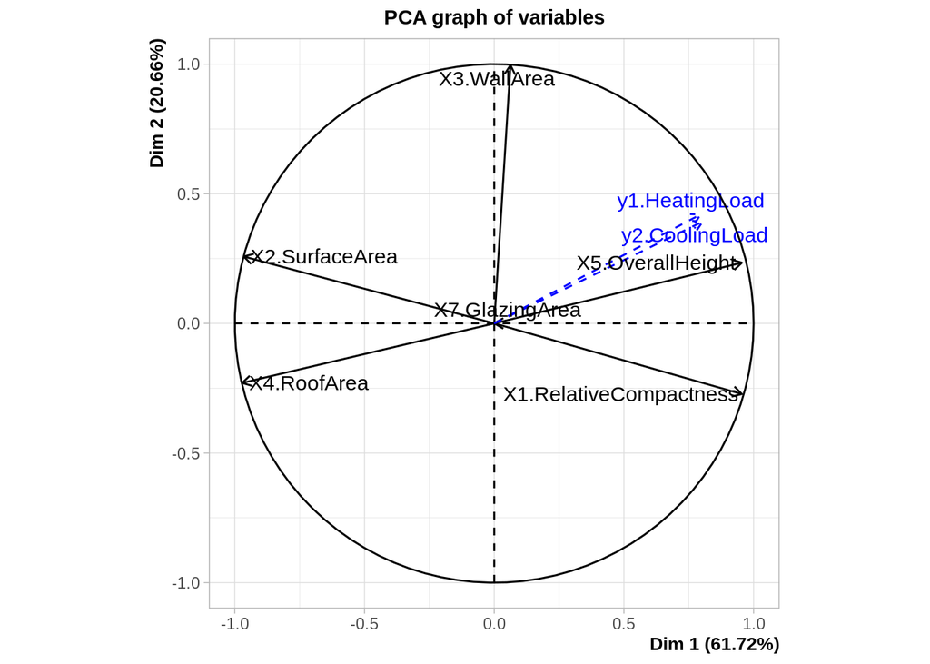

It seems that the first dimension of this PCA covers about 61% of the total variance in the dataset, and the second component covers about 20%, addding up to a total of ~80% of the total variance. Clusters of individuals are already visible from the plot of individuals.

From the screeplot we see that the first three components have almost all of the information available (~99.047%). In other words, the dimensionality of the dataset can be heavily reduced.

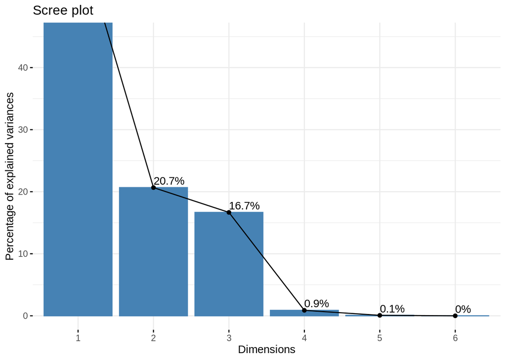

```r
fviz_screeplot(energy.pca, addlabels = TRUE, ylim = c(0, 45))
```

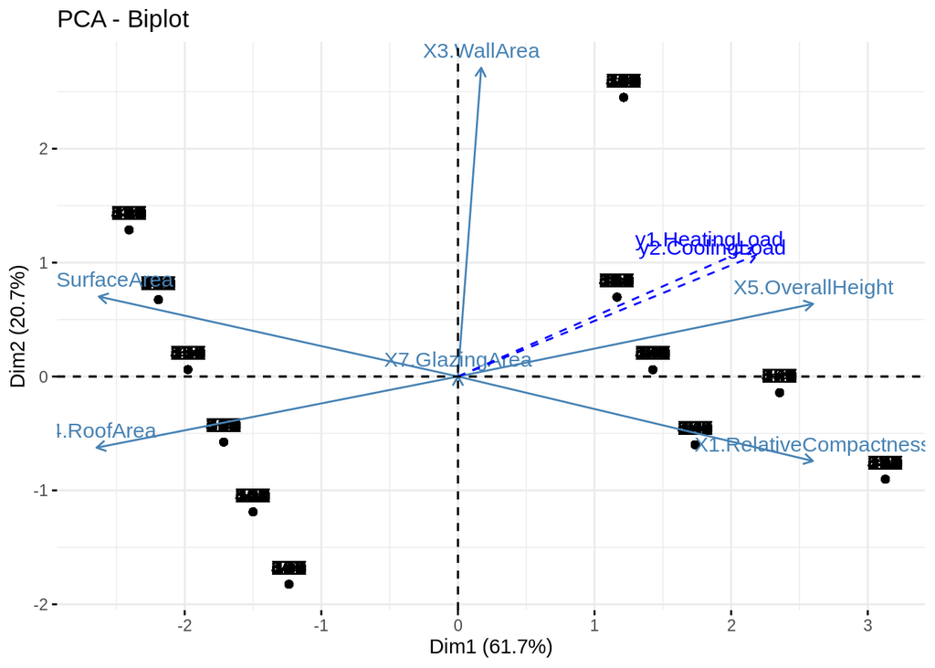

```r
fviz_pca_biplot(energy.pca)
```

```r
summary(energy.pca, ncp = 3)
```

```
##
## Call:
## PCA(X = energy, scale.unit = TRUE, quanti.sup = targets, quali.sup = categoricals)
##
##
## Eigenvalues
##                        Dim.1   Dim.2   Dim.3   Dim.4   Dim.5   Dim.6
## Variance               3.703   1.240   1.000   0.053   0.004   0.000
## % of var.             61.716  20.664  16.667   0.879   0.074   0.000
## Cumulative % of var.  61.716  82.380  99.047  99.926 100.000 100.000
##
## Individuals (the 10 first)
##                                           Dist    Dim.1    ctr   cos2    Dim.2
## 1                                     |  3.733 |  3.129  0.344  0.703 | -0.902
## 2                                     |  3.733 |  3.129  0.344  0.703 | -0.902
## 3                                     |  3.733 |  3.129  0.344  0.703 | -0.902
## 4                                     |  3.733 |  3.129  0.344  0.703 | -0.902
## 5                                     |  2.949 |  2.356  0.195  0.638 | -0.142
## 6                                     |  2.949 |  2.356  0.195  0.638 | -0.142
## 7                                     |  2.949 |  2.356  0.195  0.638 | -0.142
## 8                                     |  2.949 |  2.356  0.195  0.638 | -0.142
## 9                                     |  2.563 |  1.736  0.106  0.459 | -0.599
## 10                                    |  2.563 |  1.736  0.106  0.459 | -0.599
##                                          ctr   cos2    Dim.3    ctr   cos2
## 1                                      0.086  0.058 | -1.760  0.404  0.222 |
## 2                                      0.086  0.058 | -1.760  0.404  0.222 |
## 3                                      0.086  0.058 | -1.760  0.404  0.222 |
## 4                                      0.086  0.058 | -1.760  0.404  0.222 |
## 5                                      0.002  0.002 | -1.760  0.404  0.356 |
## 6                                      0.002  0.002 | -1.760  0.404  0.356 |
## 7                                      0.002  0.002 | -1.760  0.404  0.356 |
## 8                                      0.002  0.002 | -1.760  0.404  0.356 |
## 9                                      0.038  0.055 | -1.760  0.404  0.472 |
## 10                                     0.038  0.055 | -1.760  0.404  0.472 |
##
## Variables
##                                           Dim.1     ctr    cos2     Dim.2
## X1.RelativeCompactness                |   0.954  24.597   0.911 |  -0.273
## X2.SurfaceArea                        |  -0.965  25.174   0.932 |   0.258
## X3.WallArea                           |   0.063   0.106   0.004 |   0.996
```

[output cut: 45 more lines]

```
## X8.GlazingAreaDistribution_North        0.000   0.000   0.000 |   0.117   1.000
## X8.GlazingAreaDistribution_East         0.000   0.000   0.000 |   0.117   1.000
## X8.GlazingAreaDistribution_South        0.000   0.000   0.000 |   0.117   1.000
## X8.GlazingAreaDistribution_West         0.000   0.000   0.000 |   0.117   1.000
##                                        v.test
## X6.Orientation_North                    0.000 |
## X6.Orientation_East                     0.000 |
## X6.Orientation_South                    0.000 |
## X6.Orientation_West                     0.000 |
## X8.GlazingAreaDistribution_No Glazing -12.589 |
## X8.GlazingAreaDistribution_Uniform      1.561 |
## X8.GlazingAreaDistribution_North        1.561 |
## X8.GlazingAreaDistribution_East         1.561 |
## X8.GlazingAreaDistribution_South        1.561 |
## X8.GlazingAreaDistribution_West         1.561 |
```

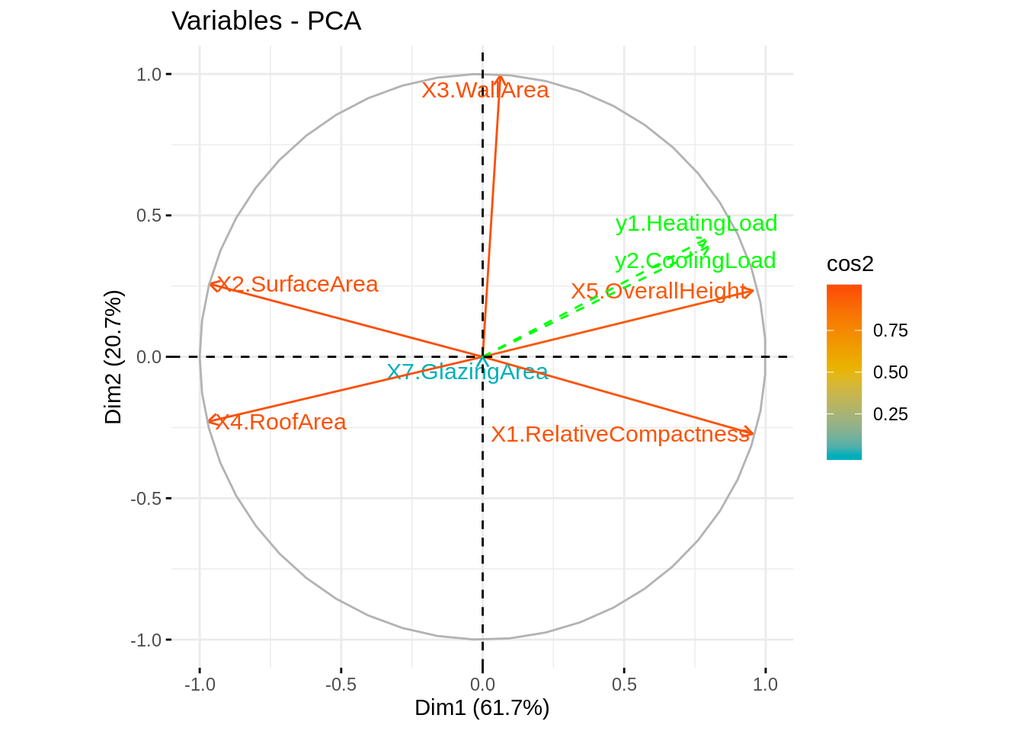

```r
# Control variable colors using their contributions
fviz_pca_var(energy.pca, col.var="cos2", col.quanti.sup = "green",
             gradient.cols = c("#00AFBB", "#E7B800", "#FC4E07"),
             repel = TRUE # Avoid text overlapping
             )
```

```r
# Control variable colors using their contributions
# currently not
fviz_pca_ind(energy.pca, col.ind = "coord",
             gradient.cols = c("#00AFBB", "#E7B800", "#FC4E07"),
             repel = FALSE # Avoid text overlapping. WARNING: If set to true it takes too much time and crashes R
             )
```

[output not shown]

# 3 Clustering

```r
energy.hcpc <- HCPC(energy.pca, nb.clust = -1, consol = FALSE)
```

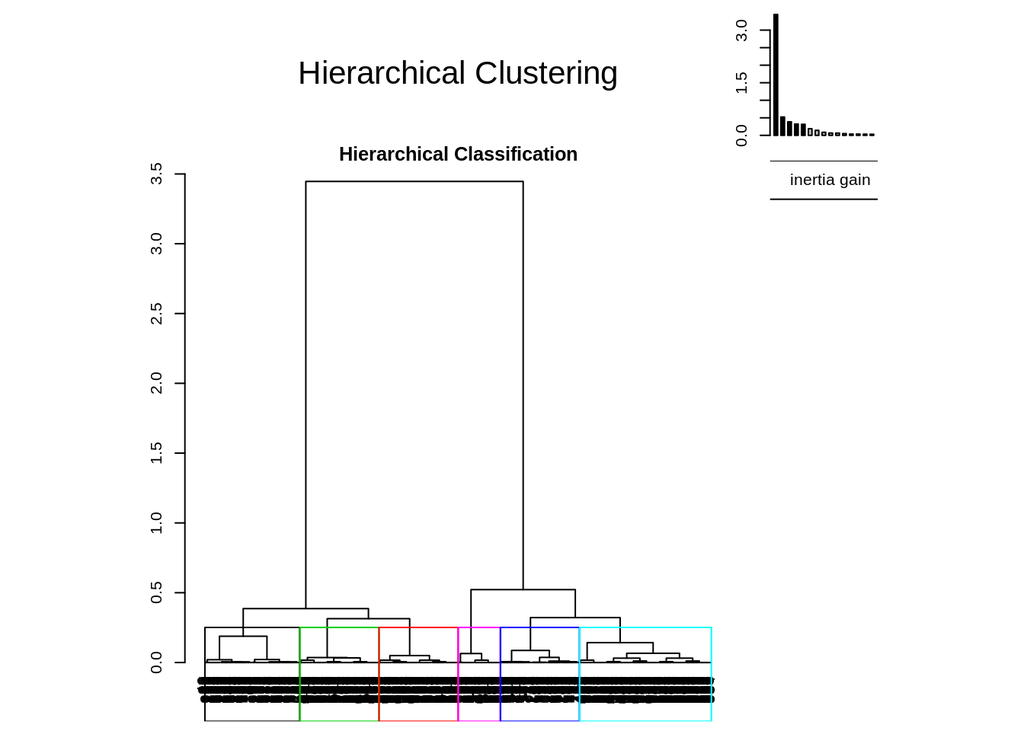

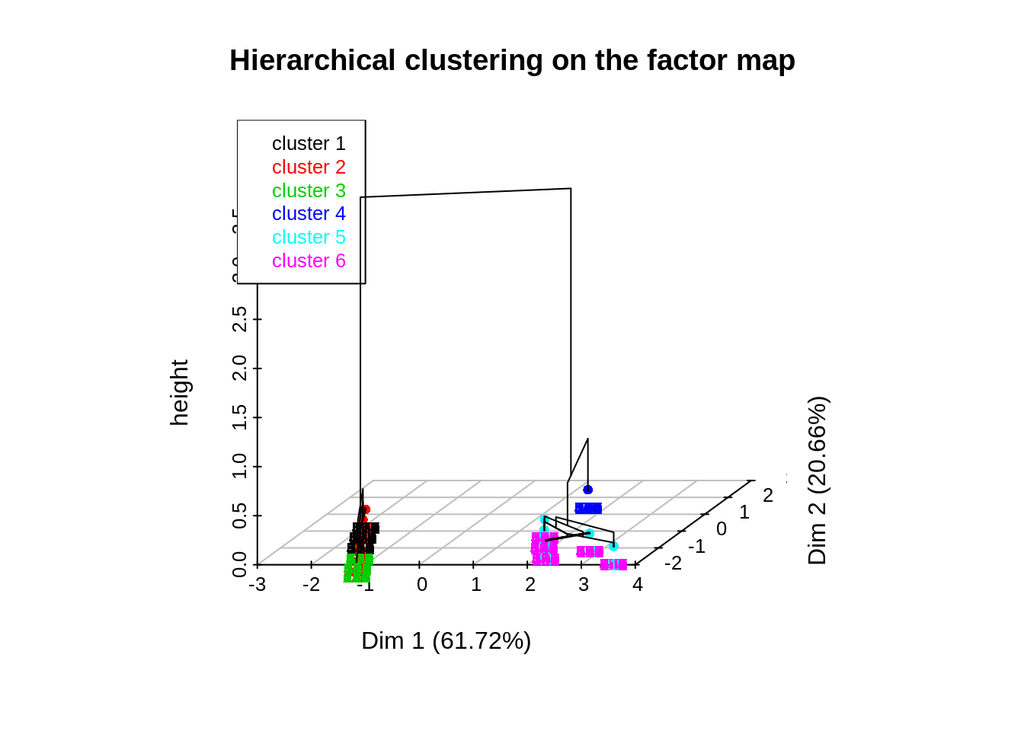

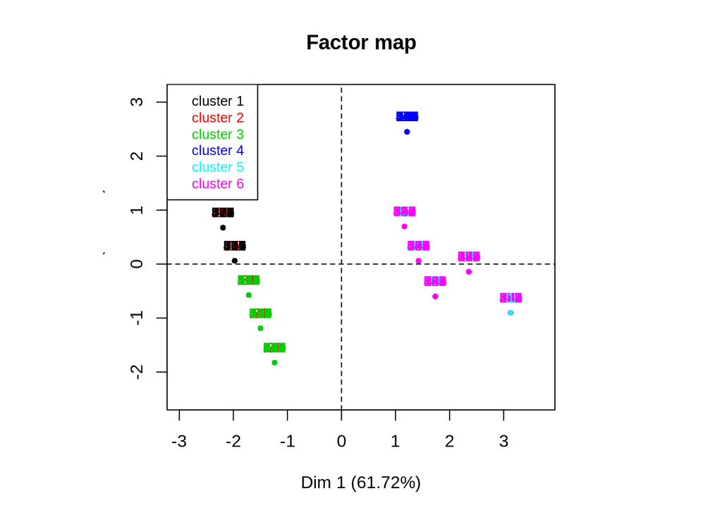

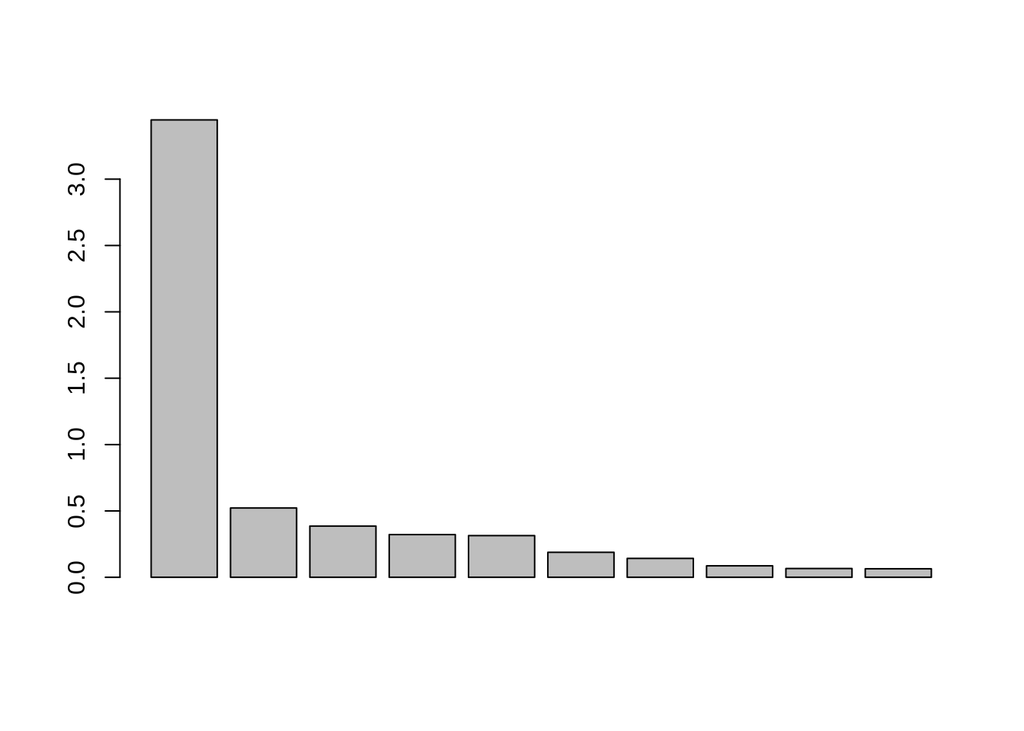

```r
barplot(energy.hcpc$call$t$inert.gain[1:10])
```

From the information above, we decide to stick with 5 clusters, *just because*.

```r
energy.hcpc.consol <- HCPC(energy.pca, nb.clust = 5, consol = TRUE)
```

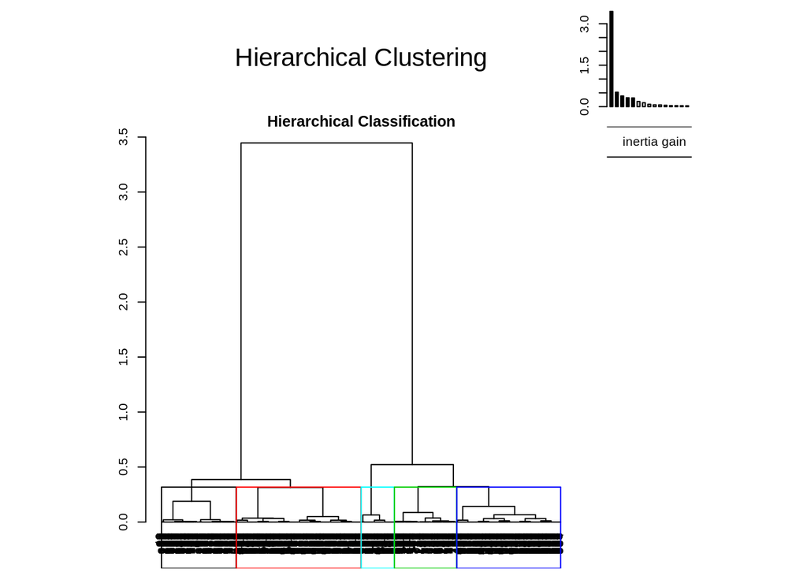

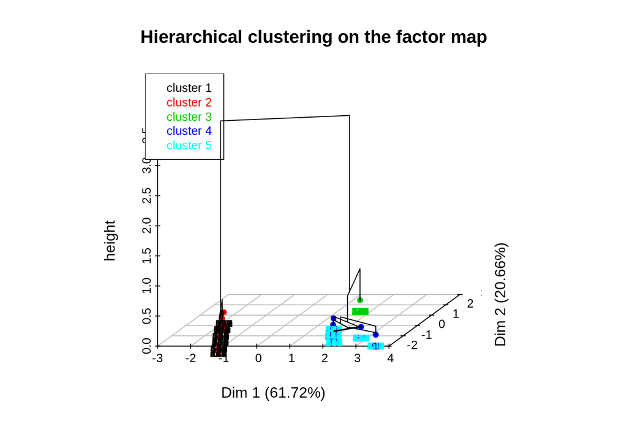

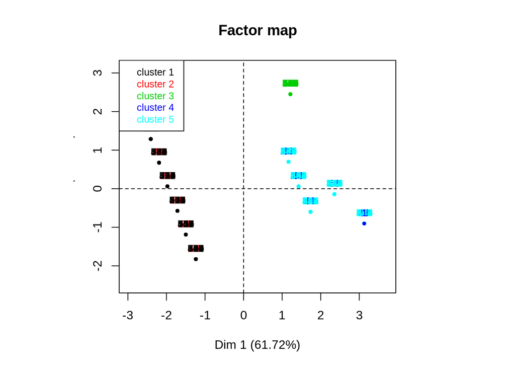